# Computational Statistics - DM/FCUP

#### (g) Graphically assess whether, in general, mothers with no literacy have their children at younger ages than literate mothers.

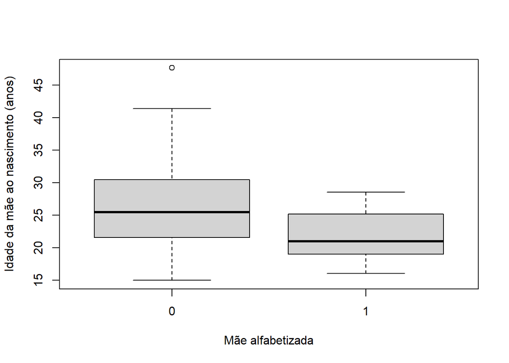

```r
ord  <- nepali[order(nepali$id, nepali$age), ]
# primeira visita de cada criança
prim <- ord[!duplicated(ord$id), ]
# idade da mãe quando a criança nasceu
prim$idade_parto <- prim$mage - prim$age / 12

boxplot(idade_parto ~ lit, data = prim,
        xlab = "Mãe alfabetizada", ylab = "Idade da mãe ao nascimento (anos)")
```

#### (h) Study, numerically and graphically, the association between the literacy of the mothers and the number of children that have died. Interpret the results.

```r
table(maes$lit)
```

```
##
##   0   1
## 878  31
```

```r
tapply(maes$died, maes$lit, mean)
```

```
##         0         1
## 0.7038724 0.0000000
```

```r
tab <- table(maes$lit, maes$died)
round(prop.table(tab, 1), 3)
```

```
##
##         0     1     2     3     4
##   0 0.582 0.229 0.104 0.074 0.011
##   1 1.000 0.000 0.000 0.000 0.000
```

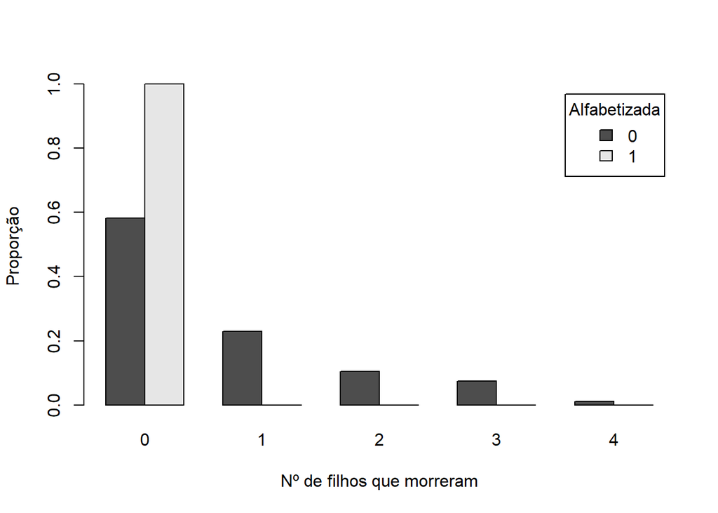

```r
barplot(prop.table(tab, 1), beside = TRUE, legend.text = TRUE,
        args.legend = list(title = "Alfabetizada"),
        xlab = "Nº de filhos que morreram", ylab = "Proporção")
```

```r
wilcox.test(died ~ lit, data = maes)
```

```
##
##  Wilcoxon rank sum test with continuity correction
##
## data:  died by lit
## W = 19298, p-value = 6.961e-06
## alternative hypothesis: true location shift is not equal to 0
```

#### (i) Describe the mothers that are aged less than 40 years-old and did not have children that died

```r
summary(subset(maes, mage < 40 & died == 0))
```

```
##        ht              mage            lit               died       alive
##  Min.   : 52.40   Min.   :17.00   Min.   :0.00000   Min.   :0   Min.   :1.00
##  1st Qu.: 75.67   1st Qu.:22.00   1st Qu.:0.00000   1st Qu.:0   1st Qu.:2.00
##  Median : 83.25   Median :26.00   Median :0.00000   Median :0   Median :3.00
##  Mean   : 83.98   Mean   :26.39   Mean   :0.06043   Mean   :0   Mean   :3.17
##  3rd Qu.: 92.72   3rd Qu.:29.00   3rd Qu.:0.00000   3rd Qu.:0   3rd Qu.:4.00
##  Max.   :110.70   Max.   :38.00   Max.   :1.00000   Max.   :0   Max.   :7.00
##  NAs    :25
```

#### (j) Is it true that older mothers tend to have more children that have died?

```r
cor(maes$mage, maes$died, method = "spearman")
```

```
## [1] 0.3822523
```

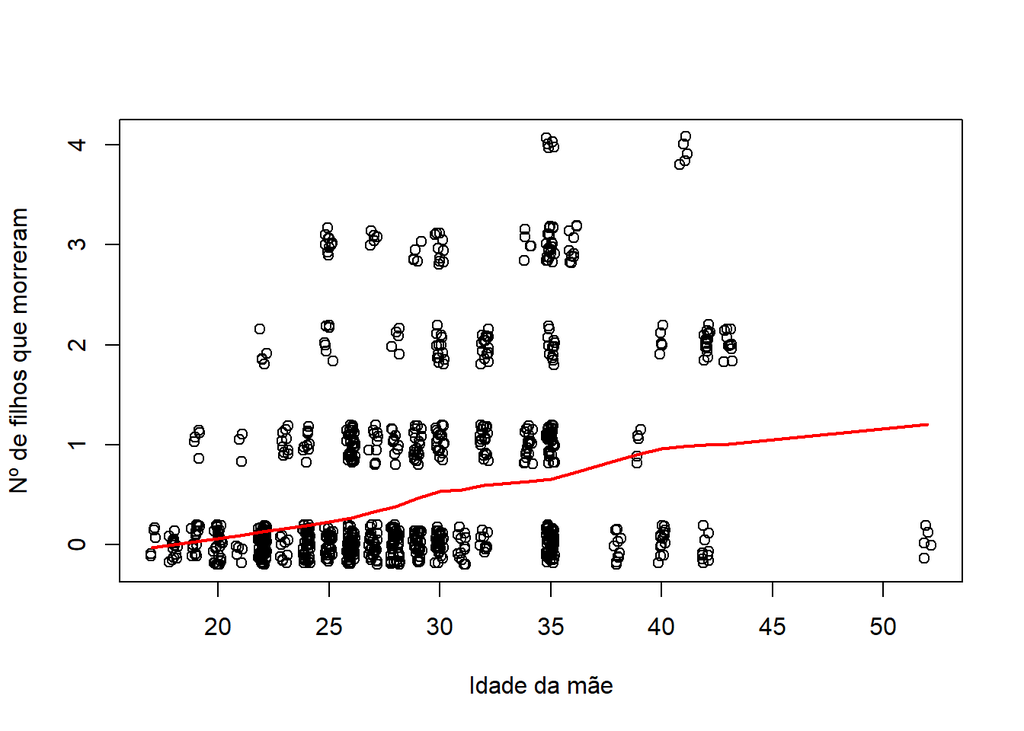

```r
plot(jitter(maes$mage), jitter(maes$died),
     xlab = "Idade da mãe", ylab = "Nº de filhos que morreram")
lines(lowess(maes$mage, maes$died), col = "red", lwd = 2)
```

#### (k) Do boys tend to be taller and heavier than girls? Give an answer based on a single plot and adequate numerical measures.

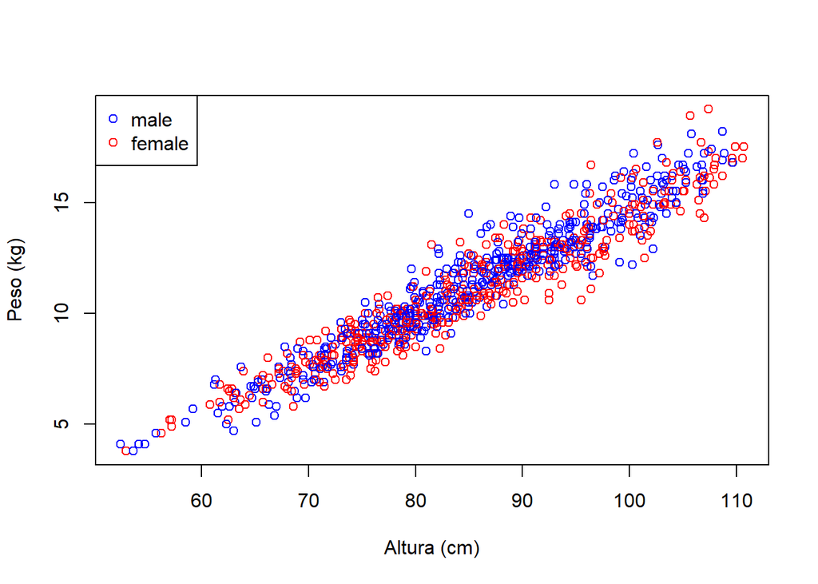

```r
plot(nepali$ht, nepali$wt, col = c("blue", "red")[nepali$sex],
     xlab = "Altura (cm)", ylab = "Peso (kg)")
legend("topleft", legend = levels(nepali$sex), col = c("blue", "red"), pch = 1)
```

```r
aggregate(cbind(ht, wt) ~ sex, data = nepali, FUN = mean)
```

```
##      sex       ht       wt
## 1   male 85.69099 11.42264
## 2 female 84.60900 10.93602
```

```r
aggregate(cbind(ht, wt) ~ sex, data = nepali, FUN = median)
```

```
##      sex    ht   wt
## 1   male 85.50 11.7
## 2 female 83.95 10.8
```

```r
aggregate(cbind(ht, wt) ~ sex, data = nepali, FUN = sd)
```

```
##      sex       ht       wt
## 1   male 11.76133 2.936628
## 2 female 12.23678 2.930928
```

#### (l) How old is the child from the youngest (resp. oldest) mother in the sample?

```r
nepali[nepali$mage == min(nepali$mage), c("id", "mage", "age")]
```

```
##         id mage age
## 786 360691   17  14
## 787 360691   17  19
## 788 360691   17  22
## 789 360691   17  26
## 790 360691   17  30
```

```r
nepali[nepali$mage == max(nepali$mage), c("id", "mage", "age")]
```

```
##        id mage age
## 86 120112   52  52
## 87 120112   52  56
## 88 120112   52  60
## 89 120112   52  64
## 90 120112   52  68
```

#### (m) MCreate a logical vector that returns the value TRUE whenever “mage”is greater than 30, and FALSE otherwise

```r
mage30 <- nepali$mage > 30
table(mage30)
```

```
## mage30
## FALSE  TRUE
##   685   315
```

#### (n) Discretize the variable representing the mothers’ ages into 3 classes as: <20 years-old; 20-34 years-old; >34 years-old. Is it true that most of the children from mothers in the younger group did not die?

```r
nepali$mage.cl <- cut(nepali$mage, breaks = c(-Inf, 20, 35, Inf),
                      right = FALSE, labels = c("<20", "20-34", ">34"))

criancas <- nepali[!duplicated(nepali$id), ]
tapply(criancas$died == 0, criancas$mage.cl, mean)
```

```
##       <20     20-34       >34
## 0.9000000 0.6597222 0.4565217
```

#### (o) The variable “age”, representing the age of each child in the sample, is in months. Create a new variable, named “age.year”, that provides each child’s age in years, with no decimal places. Obtain a single plot picturing the boxplots of weight for each age of the child (in years), using blue for the boxplots corresponding to boys and red to girls. Include a legend for colours in the picture.

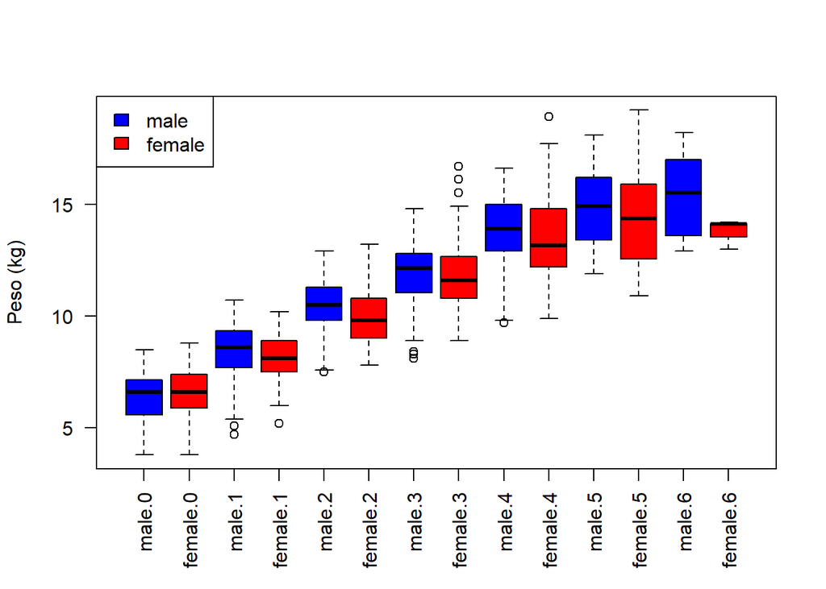

```r
nepali$age.year <- floor(nepali$age / 12)

boxplot(wt ~ sex + age.year, data = nepali,
        col = c("blue", "red"), las = 2,
        xlab = "", ylab = "Peso (kg)")
legend("topleft", legend = c("male", "female"), fill = c("blue", "red"))
```

#### (p) Export the data for girls as a comma-separated file.

```r
#write.csv(subset(nepali, sex == "female"), "nepali_girls.csv", row.names = FALSE)
```